# Data exploration PCA + variation plot

```r
result11 <- erv_func(file11)
result12 <- erv_func(file12)
```

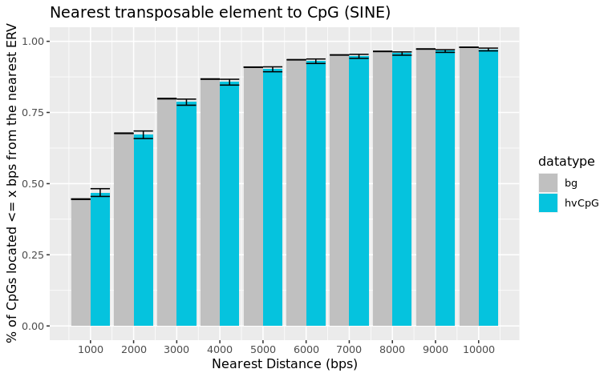

[figure not shown]

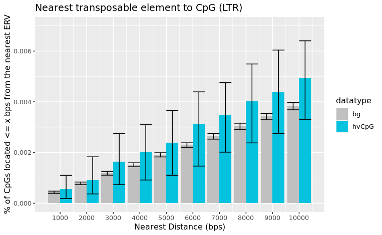

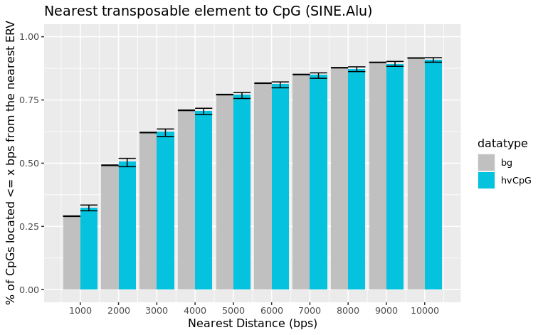

```r
result17 <- erv_func(file17) #long running time
```

```
[1] "/mnt/data/RepeatMasker/regions/hg19.repeat_masker.SINE.Deu.bed"
[1] "===nearestCpG===="
[1] "bg"
```

```r
head(result8)
```

[output not shown]

#Variation of the the function that calculates TE enrichment for declustered SiV-CpGs #this function only analysing 1000-10000 by 1000 interval, else code needs to be changes a bit

```r
#run function to get the distance of CpG to the nearest erv for background CpGs
#776492 here is the total number of CpG in gd
re.plt.bg <- nearestCpG(row.names(EPIC.norm.beta.DF), dtype="Background", 776492, transposon.gr) #doesn't need to be run every time
names(re.plt.bg) <- c("distance", "upper.b", "lower.b", "cu.percent","datatype")

erv_func.decluster <- function(input_file){
  print(input_file)
  #getting the erv file into a df from trans file
  trans <- read.table(input_file,header = FALSE, sep="\t",stringsAsFactors=FALSE, quote="")
  colnames(trans) <- c("chr", "start", "end", "line", "L", "strand", "L_")
  #convert the df into gr object
  transposon.gr <- makeGRangesFromDataFrame(trans,
                           keep.extra.columns=FALSE,
                           ignore.strand=FALSE,
                           seqinfo=NULL,
                           seqnames.field=c("seqnames", "seqname",
                                            "chromosome", "chrom",
                                            "chr", "chromosome_name",
                                            "seqid"),
                           start.field="start",
                           end.field=c("end", "stop"),
                           strand.field="strand",
                           starts.in.df.are.0based=FALSE)

  #run function to get the distance of CpG to the nearest erv for identified HvCpGs
  #2050 here is the total number of CpG in identified SiV
  re.plt.hvcpg <- nearestCpG(CpG_decluster, dtype="SiVCpG", 907, transposon.gr)
  names(re.plt.hvcpg) <- c("distance", "upper.b", "lower.b", "cu.percent","datatype")

  #combine two dfs
  re.plt.all <- rbind(re.plt.bg, re.plt.hvcpg)

  #double check column names
  names(re.plt.hvcpg)<- c("distance", "upper.b", "lower.b", "cu.percent","datatype")

  #plot bar plot

  ggplot(re.plt.all, aes(x=distance, y=cu.percent, fill=datatype)) +
    geom_bar(position=position_dodge(), stat="identity") +
    geom_errorbar(aes(ymin = lower.b, ymax = upper.b, group=datatype),position=position_dodge()) +
    ylim(0,0.04) +
    scale_x_continuous(breaks=seq(1000,10000,1000)) +
    ggtitle("Nearest transposable element to CpG (LTR.all_HERV) ")  +
    xlab("Nearest Distance (bps)") + ylab("% of CpGs located <= x bps from the nearest ERV") +
    scale_fill_manual(values = c("#C0C0C0","#05C3DE"))

  return(re.plt.all)
}
```

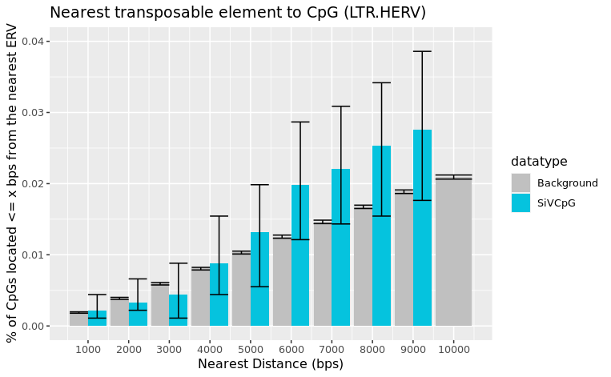

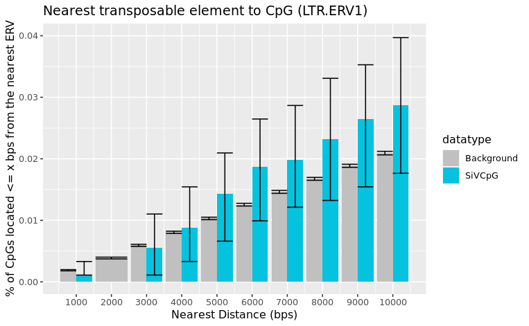

[figure not shown]

```r
  ggplot(decluster.result8 , aes(x=distance, y=cu.percent, fill=datatype)) +
    geom_bar(position=position_dodge(), stat="identity") +
    geom_errorbar(aes(ymin = lower.b, ymax = upper.b, group=datatype),position=position_dodge()) +
    ylim(0,0.04) +
    scale_x_continuous(breaks=seq(1000,10000,1000)) +
    ggtitle("Nearest transposable element to CpG (LTR.ERVK) ")  +
    xlab("Nearest Distance (bps)") + ylab("% of CpGs located <= x bps from the nearest ERV") +
    scale_fill_manual(values = c("#C0C0C0","#05C3DE"))
```

```r
decluster.result7 <- erv_func.decluster(file7)
ggplot(decluster.result7, aes(x=distance, y=cu.percent, fill=datatype)) +
    geom_bar(position=position_dodge(), stat="identity") +
    geom_errorbar(aes(ymin = lower.b, ymax = upper.b, group=datatype),position=position_dodge()) +
    ylim(0,0.037) +
    scale_x_continuous(breaks=seq(1000,10000,1000)) +
    ggtitle("Nearest transposable element to CpG (LTR.ERVK) ") +
    xlab("Nearest Distance (bps)") + ylab("% of CpGs located <= x bps from the nearest TE") +
    scale_fill_manual(values = c("#C0C0C0","#05C3DE"))
```

[output not shown]

```r
decluster.result10 <- erv_func.decluster(file10)

ggplot(decluster.result10, aes(x=distance, y=cu.percent, fill=datatype)) +
    geom_bar(position=position_dodge(), stat="identity") +
    geom_errorbar(aes(ymin = lower.b, ymax = upper.b, group=datatype),position=position_dodge()) +
    ylim(0,0.035) +
    scale_x_continuous(breaks=seq(1000,10000,1000)) +
    ggtitle("Nearest transposable element to CpG (LTR.all_HERV) ") +
    xlab("Nearest Distance (bps)") + ylab("% of CpGs located <= x bps from the nearest TE")  +
    scale_fill_manual(values = c("#C0C0C0","#05C3DE"))
```

[output not shown]

#modified nearestCpG function to analyse effect of interindividual variation on distance to nearest TE

```r
#load manifest before hand, get ready with transposon.gr which is the gr object for erv
nearestCpG.mod <- function(Cpg.list, dtype, bs.size, transposon.gr) {
  print(c("===nearestCpG====", dtype))
  #Get chr, pos, strand info from manifest
  bg.df <- manifest %>% filter(Name %in% Cpg.list) %>% select(chr, pos, strand)
  bg.df$end <- bg.df$pos
  names(bg.df) <- c("chr", "start", "strand", "end")
  #convert df into a gr object
  bg.gr <- makeGRangesFromDataFrame(bg.df,
                           keep.extra.columns=FALSE,
                           ignore.strand=FALSE,
                           seqinfo=NULL,
                           seqnames.field=c("seqnames", "seqname",
                                            "chromosome", "chrom",
                                            "chr", "chromosome_name",
                                            "seqid"),
                           start.field="start",
                           end.field=c("end", "stop"),
                           strand.field="strand",
                           starts.in.df.are.0based=FALSE)

  #The subject (in this case bg.gr) is the
  #GenomicRanges instance within which the nearest neighbours are found.
  #Can be missing, in which case x is also the subject.

  #Use distanceToNearest function to find out the distance of the nearest erv to each CpG
  dist.bg <- distanceToNearest(bg.gr, transposon.gr, select=c("all"),ignore.strand=FALSE)
  #get the distance info from gr object
  df_ <- mcols(dist.bg) %>% as.data.frame()
  #binning
  df_10k <- df_ %>% filter(distance < 100000)

  return (c(dim(df_10k)[1]/dim(df_)[1], dtype))

}
```

#modified erv function to analyse effect of interindividual variation on distance to nearest TE

```r
#modified erv function to analyse effect of interindividual variation on distance to nearest TE

#this function only analysing 1000-10000 by 1000 interval, else code needs to be changes a bit
erv_func.mod <- function(input_file, SiVCpg, datatype){
  #getting the erv file into a df from trans file
  trans <- read.table(input_file,header = FALSE, sep="\t",stringsAsFactors=FALSE, quote="")
  colnames(trans) <- c("chr", "start", "end", "line", "L", "strand", "L_")
  #convert the df into gr object
  transposon.gr <- makeGRangesFromDataFrame(trans,
                           keep.extra.columns=FALSE,
                           ignore.strand=FALSE,
                           seqinfo=NULL,
                           seqnames.field=c("seqnames", "seqname",
                                            "chromosome", "chrom",
                                            "chr", "chromosome_name",
                                            "seqid"),
                           start.field="start",
                           end.field=c("end", "stop"),
                           strand.field="strand",
                           starts.in.df.are.0based=FALSE)

  #run function to get the distance of CpG to the nearest erv for background CpGs
  #776492 here is the total number of CpG in gd
  re.plt.bg <- nearestCpG.mod(row.names(EPIC.norm.beta.DF), dtype=paste(datatype,"bg"), 776492, transposon.gr)
  print("re.plt.bg")
  #run function to get the distance of CpG to the nearest erv for identified HvCpGs
  #2050 here is the total number of CpG in identified SiV
  re.plt.hvcpg <- nearestCpG.mod(SiVCpg, dtype=paste(datatype, "SiVCpG"), dim(SiVCpg)[1], transposon.gr)
  print("re.plt.hvcbg")
  #combine two dfs
  re.plt.all <- rbind(re.plt.bg, re.plt.hvcpg)

  return(re.plt.all)
}
```

#add label of interindividual variation in the df

```r
var.threshold %>% dim(
)
```

```
[1] 5464    3
```

#calculating percentage difference between siv cpg and bg cpg in terms of TE enrichment (count to nearest TE with x bps)

[figure not shown]

#Modified function for calculating raw number

```r
nearestCpG.mod.count <- function(Cpg.list, dtype, bs.size, transposon.gr) {
  print(c("===nearestCpG====", dtype))
  #Get chr, pos, strand info from manifest
  bg.df <- manifest %>% filter(Name %in% Cpg.list) %>% select(chr, pos, strand)
  bg.df$end <- bg.df$pos
  names(bg.df) <- c("chr", "start", "strand", "end")
  #convert df into a gr object
  bg.gr <- makeGRangesFromDataFrame(bg.df,
                           keep.extra.columns=FALSE,
                           ignore.strand=FALSE,
                           seqinfo=NULL,
                           seqnames.field=c("seqnames", "seqname",
                                            "chromosome", "chrom",
                                            "chr", "chromosome_name",
                                            "seqid"),
                           start.field="start",
                           end.field=c("end", "stop"),
                           strand.field="strand",
                           starts.in.df.are.0based=FALSE)

  #The subject (in this case bg.gr) is the
  #GenomicRanges instance within which the nearest neighbours are found.
  #Can be missing, in which case x is also the subject.

  #Use distanceToNearest function to find out the distance of the nearest erv to each CpG
  dist.bg <- distanceToNearest(bg.gr, transposon.gr, select=c("all"),ignore.strand=FALSE)
  #get the distance info from gr object
  df_ <- mcols(dist.bg) %>% as.data.frame()
  #binning
  df_10k <- df_ %>% filter(distance < 100000)

  return (c(dim(df_10k)[1], dtype))

}
```